# Quiz #1 - Partial Solution

Your Name

Last knit on January 30, 2018 at 06:08:32 PM

**Directions: Change the author field in the `YAML` from “Your Name” to your name using the convention of FirstName LastName. For example, my entry would be `author: "Alan Arnholt"`. The data frame `Y1980` contains the variables `teamID`, `W`, `L`, and `attendance` for the year 1980. Create a `Quizzes` directory inside your private repository. Store this file as `Quiz01.Rmd` inside the `Quizzes` directory. When you finish, commit your changes and push your work to GitHub. Use the commit message `Finished Quiz 01!`. Verify you can see your files at `https://github.com/STAT-ATA-ASU/YourLast-YourFirst-STT5812-SP18/tree/master/Quizzes`.**

```r
library(Lahman)
library(dplyr)
Y1980 <- Teams %>%
  filter(yearID == 1980) %>%
  select(teamID, W, L, attendance)
head(Y1980)  # show frist six rows
```

```
  teamID   W  L attendance
1    ATL  81 80    1048411
2    BAL 100 62    1797438
3    BOS  83 77    1956092
4    CAL  65 95    2297327
5    CHA  70 90    1200365
6    CHN  64 98    1206776
```

1. Create a histogram or density plot showing the distribution of the variable `attendance` from the data frame `Y1980`.

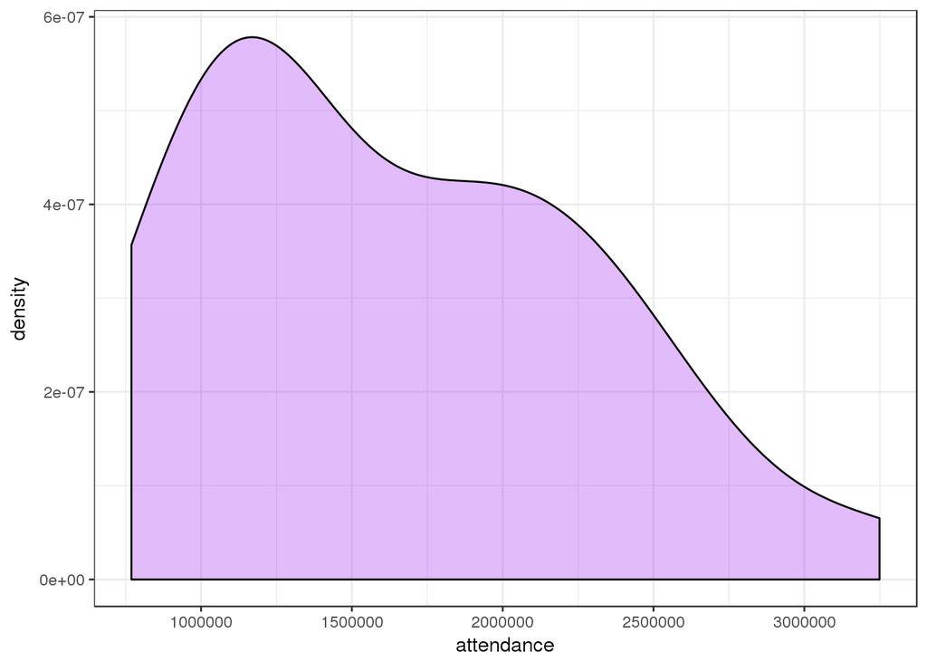

```r
# Your Code here
library(ggplot2)
ggplot(data = Y1980, aes(x = attendance)) +
  geom_density(fill = "purple", alpha = 0.3) +
  theme_bw()
```

2. Create a quantile-quantile plot of the variable `attendance` from the data frame `Y1980`.

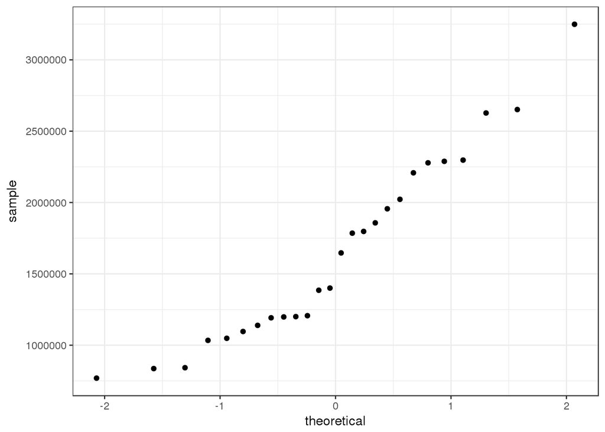

```r
# Your code here
ggplot(data = Y1980, aes(sample = attendance)) +
  stat_qq() +
  theme_bw()
```

```r
shapiro.test(Y1980$attendance)
```

```
    Shapiro-Wilk normality test

data:  Y1980$attendance
W = 0.93649, p-value = 0.1107
```

3. Assume the conditions for constructing a confidence interval for $\mu$ based on a $t$ distribution are satisfied. Find a report the following values assuming $\alpha = 0.10$:
1. $\bar{x} =1.6543898\times 10^{6}$
2. $s =6.5450639\times 10^{5}$
3. $n =26$
4. $t_{1 - \alpha/2,\, n -1} =1.708$
5. $CI_{1 - \alpha}(\mu) =[1.4351342\times 10^{6}, 1.8736455\times 10^{6}]$

**Extra Credit: if you use inline R to answer a-e.**

```r
# Your code here
alpha <- 0.10
xbar <- mean(Y1980$attendance)
s <- sd(Y1980$attendance)
n <- sum(!is.na(Y1980$attendance))
CT <- qt(1 - alpha/2, n - 1)
SE <- s/sqrt(n)
ME <- CT*SE
lcl <- xbar - ME
ucl <- xbar + ME
round(c(xbar, s, n, CT, SE, ME, lcl, ucl), 4)
```

```
[1] 1654389.8462  654506.3872      26.0000       1.7081  128359.2631
[6]  219255.6893 1435134.1568 1873645.5355
```

```r
t.test(Y1980$attendance, conf.level = 0.90)$conf
```

```
[1] 1435134 1873646
attr(,"conf.level")
[1] 0.9
```

```r
# Using tidyverse
Y1980 %>%
  summarize(xbar = mean(attendance), s = sd(attendance), n = sum(!is.na(attendance))) %>%
  mutate(CT = qt(1 - alpha/2, n - 1), lcl = xbar - CT*s/sqrt(n), ucl = xbar +CT*s/sqrt(n))
```

```
     xbar        s  n       CT     lcl     ucl
1 1654390 654506.4 26 1.708141 1435134 1873646
```